# Web Traffic Time Series Forecasting

Devanshi Verma

11/27/2020

### Overview

#### Description

We decided to work on one of the most burning time series problem of today’s day and era, “predicting web traffic”. We believe that this forecasting can help website servers a great deal in effectively handling outages. The technique we implemented can be extended to diverse applications in financial markets, weather forecasts, audio and video processing. Not just that, understanding your website’s traffic trajectory can open up business opportunities too!

#### Dataset

Let’s import the important libraries

```r
# visualization
library('ggplot2')

# data manipulation
library('dplyr')
library('readr')
library('imputeTS')


#time series
library('fpp')
library('forecast')
library('xts')
library('zoo')
```

### Data Preparation

A dataset like this would have a lot of interventions because the web traffic views are dependent on external factors and can spike up on one day and return to the same level in a while. So let’s start with searching a nice stationary model wave where we can use our ARIMA methods, and then we can start working on interventions

```r
# importing the dataset
train_1 <- read.csv("~/Desktop/UChicago/Quarters/03-Quarters/Data/TS/web-traffic-time-series-forecasting/train_1.csv", header = TRUE, row.names = 1,sep = ",",skip =0)
```

We found one dataset that appears more or less stationary, let’s have a look

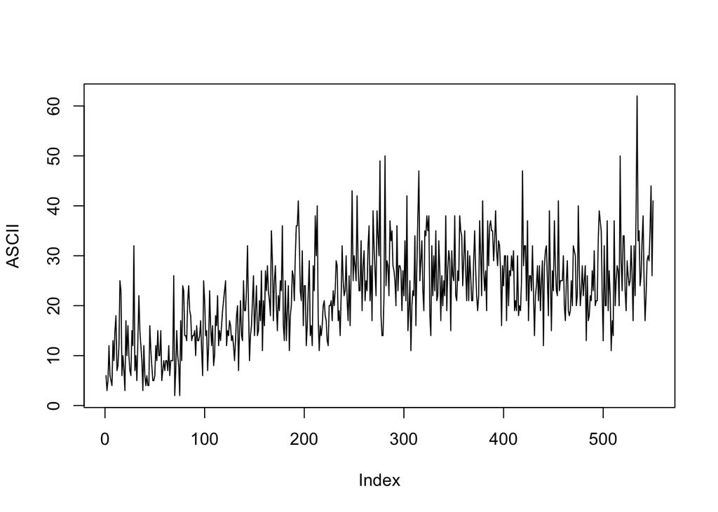

```r
# importing the dataset
ASCII <- data.matrix(train_1[c("ASCII_zh.wikipedia.org_all-access_spider"),])
dimnames(ASCII)<-NULL
ASCII<-array(ASCII)
plot(ASCII,type='l')
```

The time series appears to have increasing trend with no signs of seasonality

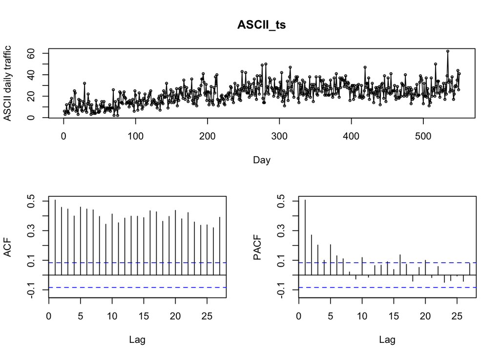

```r
time_index <- seq(from = as.POSIXct("2015-07-01"), to = as.POSIXct("2016-12-31"), by = "day")
ASCII_ts <- xts(ASCII, order.by =time_index ,frequency = 365.25)
tsdisplay(ASCII_ts,ylab="ASCII daily traffic",xlab="Day")
```

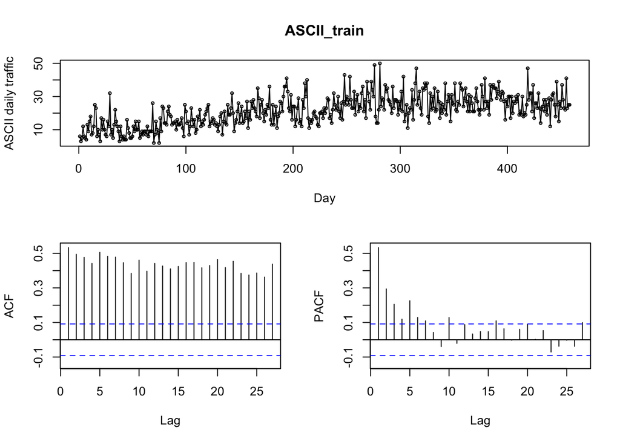

```r
ASCII_train<-ASCII_ts['2015-07-01/2016-09-30']
ASCII_test<-ASCII_ts['2016-10-01/2016-12-31']
tsdisplay(ASCII_train,ylab="ASCII daily traffic",xlab="Day")
```

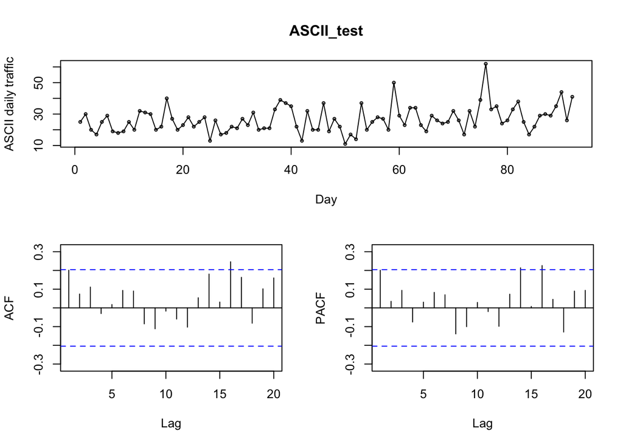

```r
tsdisplay(ASCII_test,ylab="ASCII daily traffic",xlab="Day")
```

```r
length(ASCII_test)
```

```
## [1] 92
```

We can see from ACF and PACF that the dataset isn’t dying down fast which means that the dataset isn’t stationary and hence we would need differencing. Let’s have a look at that as well.

Let’s look if we need to do Box Cox transformation to decouple mean and variance

```r
BoxCox.lambda(ASCII_train)
```

```
## [1] 0.3897714
```

Also confirming our assumption that the data isn’t stationary

```r
kpss.test(ASCII_train)
```

```
##
##  KPSS Test for Level Stationarity
##
## data:  ASCII_train
## KPSS Level = 5.6063, Truncation lag parameter = 5, p-value = 0.01
```

Since the p value is less than 0.05, the data isn’t stationary

Let’s apply one level of differencing and check

```r
ASCII_train_boxcox<-ASCII_train %>% BoxCox(lambda = BoxCox.lambda(ASCII_train))
ASCII_train_diff <- diff(ASCII_train_boxcox)
kpss.test(ASCII_train_diff)
```

```
##
##  KPSS Test for Level Stationarity
##
## data:  ASCII_train_diff
## KPSS Level = 0.017647, Truncation lag parameter = 5, p-value = 0.1
```

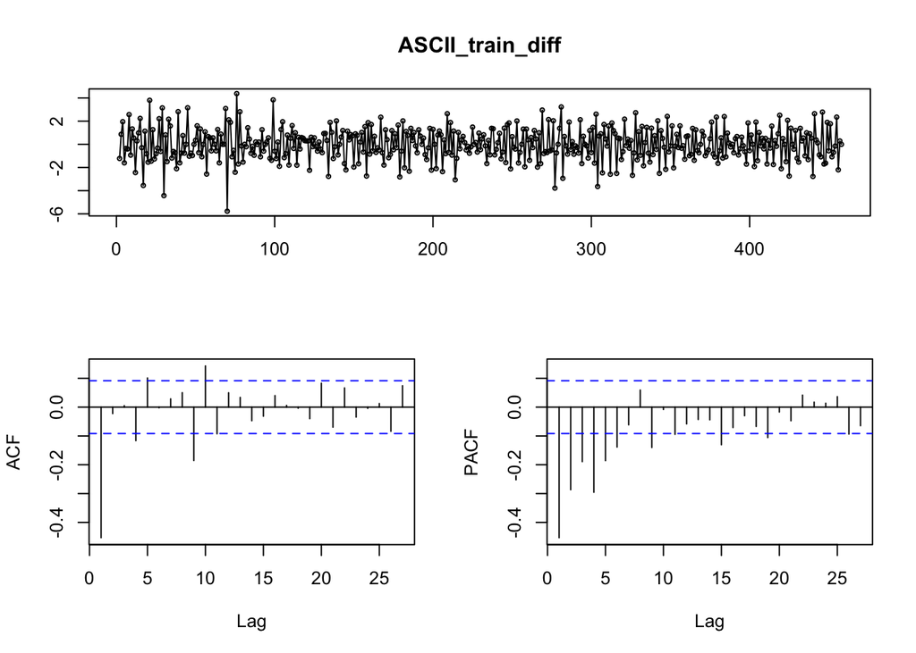

```r
tsdisplay(ASCII_train_diff)
```

### Naive Forecasts

The data is better now, and the looks stationary. Let’s start with naive forecasts first before we movie into ARIMA model

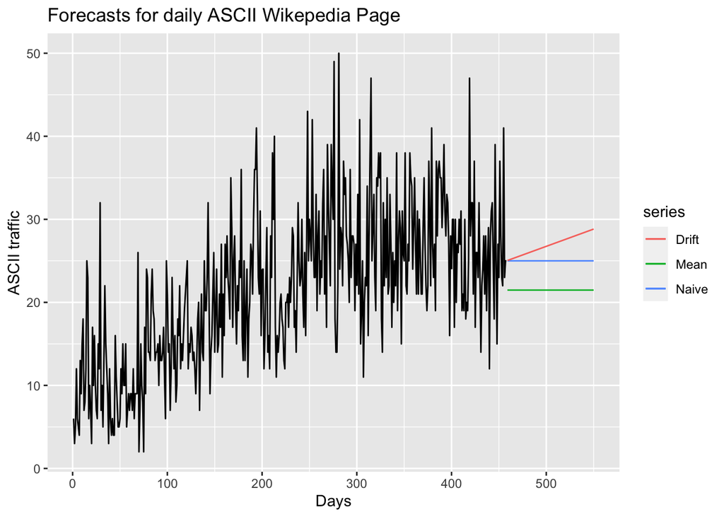

```r
#forecast horizon
h<-92
#naive forecasts
ASCII_train_new<-ts(ASCII_ts['2015-07-01/2016-09-30'])
ASCII_test_new<-ts(ASCII_ts['2016-10-01/2016-12-31'])

#evaluating the models
Model_Mean <- meanf(ASCII_train_new, h)
Model_Naive <- naive(ASCII_train_new, h)
Model_Drift <- rwf(ASCII_train_new, h, drift=TRUE)

#Naive forecast
autoplot(ASCII_train_new) +
  autolayer(Model_Mean$mean, series="Mean") +
  autolayer(Model_Naive$mean, series="Naive") +
  autolayer(Model_Drift$mean, series="Drift") +
  ggtitle("Forecasts for daily ASCII Wikepedia Page") +
  xlab("Days") + ylab("ASCII traffic")
```

Let’s have a look at the metrics - Out of sample metrics-test

```r
accuracy(Model_Mean,ASCII_test)
```

```
##                        ME     RMSE      MAE       MPE     MAPE      MASE
## Training set 1.288732e-15 9.247481 7.477975 -35.02098 58.12142 0.3481664
## Test set     5.076182e+00 9.681532 7.009018  11.46968 23.96929 0.3263323
##                   ACF1
## Training set 0.5328766
## Test set            NA
```

```r
accuracy(Model_Naive,ASCII_test)
```

```
##                      ME     RMSE      MAE        MPE     MAPE      MASE
## Training set 0.04157549 8.917198 6.956236 -12.684160 40.37525 0.3238748
## Test set     1.55434783 8.389305 6.228261  -3.046881 24.13922 0.2899810
##                    ACF1
## Training set -0.4634768
## Test set             NA
```

```r
accuracy(Model_Drift,ASCII_test)
```

```
##                         ME     RMSE      MAE       MPE     MAPE      MASE
## Training set  4.791771e-16 8.917101 6.959238 -12.94458 40.45229 0.3240146
## Test set     -3.789126e-01 7.981986 6.161046 -10.65661 25.72335 0.2868516
##                    ACF1
## Training set -0.4634768
## Test set             NA
```

It can be seen from above metrics that drift is performing the best because the trend is increasing but not a stable model as the assumption is that it would always increase. Let’s have a look at the ARIMA model

### ARIMA Model

```r
auto.arima(ASCII_train,seasonal = TRUE,lambda = 'auto')
```

```
## Series: ASCII_train
## ARIMA(2,1,3) with drift
## Box Cox transformation: lambda= 0.3897714
##
## Coefficients:
##          ar1      ar2      ma1     ma2      ma3   drift
##       0.7449  -0.9047  -1.5888  1.4992  -0.8159  0.0073
## s.e.  0.0570   0.0682   0.0683  0.1202   0.0668  0.0042
##
## sigma^2 estimated as 1.153:  log likelihood=-678.97
## AIC=1371.94   AICc=1372.19   BIC=1400.82
```

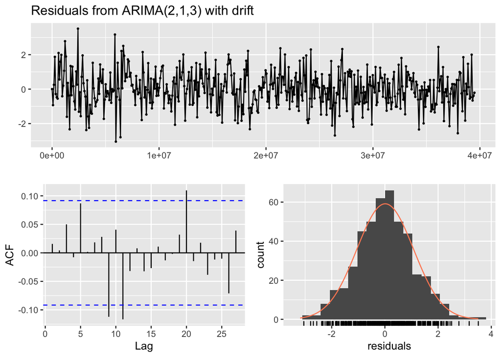

```
##
##  Ljung-Box test
##
## data:  Residuals from ARIMA(2,1,3) with drift
## Q* = 12.022, df = 4, p-value = 0.01719
##
## Model df: 6.   Total lags used: 10
```

```r
m1<-Arima(ASCII_train,lambda = 'auto',order=c(2,1,3),include.drift = TRUE)
checkresiduals(m1)
```

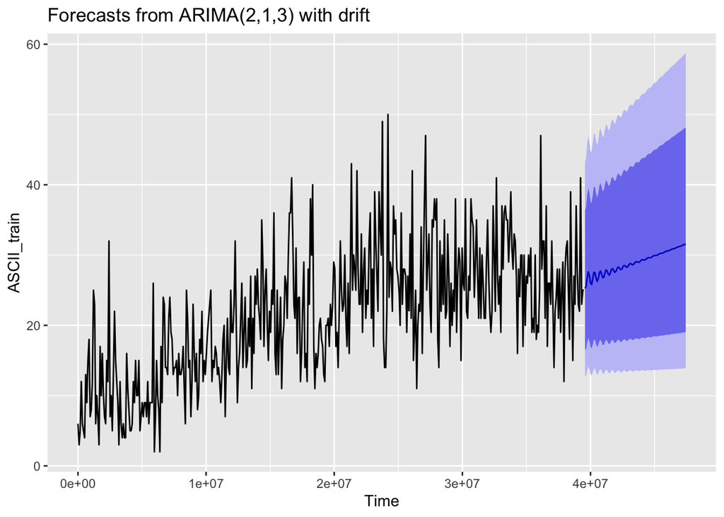

```r
autoplot(forecast(m1,h=92))
```

```r
accuracy(forecast(m1,h=92),ASCII_test)
```

```
##                      ME     RMSE      MAE        MPE     MAPE     MASE
## Training set  0.5616526 6.780914 5.236161  -8.861843 29.96078 0.243790
## Test set     -2.3523442 8.302841 6.700521 -18.718375 29.63149 0.311969
##                     ACF1
## Training set 0.001079399
## Test set              NA
```

#### EACF - ARIMA

Let’s check if there are better model using the Extended Auto correlation function

```r
source("~/Desktop/UChicago/Quarters/03-Quarters/03-31006-TimeSeries/03-Week/eacf.r")
#differencing and box cox transforming the training data
ASCII_train_new_boxcox<-ASCII_train_new %>% BoxCox(lambda = BoxCox.lambda(ASCII_train_new))
ASCII_train_new_diff <- diff(ASCII_train_new_boxcox)
eacf(ASCII_train_new_diff)
```

```
## AR/MA
##   0 1 2 3 4 5 6 7 8 9 10 11 12 13
## 0 x o o x x o o o x x o  o  o  o
## 1 x x o x x o o o x o o  o  o  o
## 2 x o o x x o o o x o o  x  o  o
## 3 x x x x o o o o x o o  o  o  o
## 4 x o x x x o o o x o x  o  o  o
## 5 x x o o x x o o o o x  o  o  o
## 6 x x o o x o o o o o x  o  o  o
## 7 x o x x x o x x o o x  o  o  x
```

Note: We don’t wish to complicate the model and hence would keep pmax and qmax to be 2,2 Trying different models from above matrix p=0,q=1 p=0,q=2 p=1,q=2 p=2,q=1 p=2,q=2

```r
m2<-Arima(ASCII_train,lambda = 'auto',order=c(0,1,1),include.drift = TRUE)
m3<-Arima(ASCII_train,lambda = 'auto',order=c(0,1,2),include.drift = TRUE)
m4<-Arima(ASCII_train,lambda = 'auto',order=c(1,1,2),include.drift = TRUE)
m5<-Arima(ASCII_train,lambda = 'auto',order=c(2,1,1),include.drift = TRUE)
m6<-Arima(ASCII_train,lambda = 'auto',order=c(2,1,2),include.drift = TRUE)
cbind(m1$aicc,m2$aicc,m3$aicc,m4$aicc,m5$aicc,m6$aicc)
```

```
##          [,1]     [,2]     [,3]     [,4]     [,5]     [,6]
## [1,] 1372.194 1378.982 1376.102 1377.536 1377.471 1379.025
```

By Aicc values, model1 is the best. Therefore we would go with auto arima model.

### Cross Validation

Let’s use the best model found i.e. ARIMA(2,1,3)

```r
m7 <- function(x, h){forecast(Arima(x, order=c(2,1,3),lambda = 'auto',include.drift=TRUE), h=h)}
error_1 <- tsCV(ASCII_train, m7, h=1)
error_2 <- tsCV(ASCII_train, m7, h=1, window = 12) # Rolling/Sliding Window
```

Let’s have look at the errors

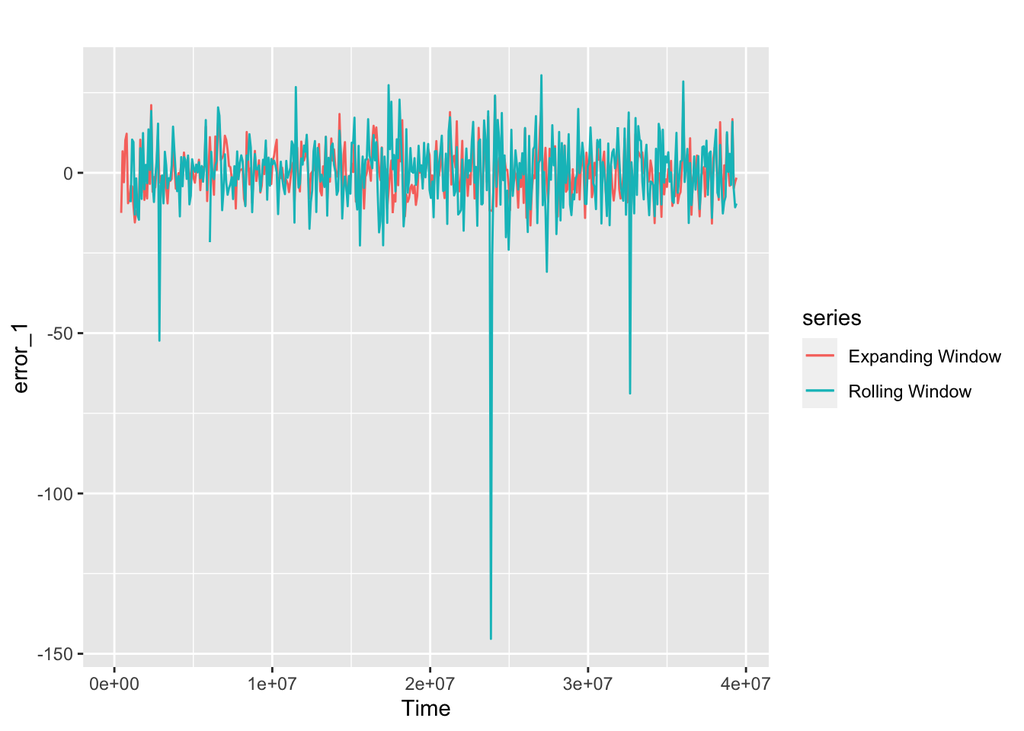

```r
autoplot(error_1, series = 'Expanding Window') +
  autolayer(error_2, series = 'Rolling Window')
```

Let’s have a look at the values as well

```r
print(sqrt(mean(error_1^2, na.rm=TRUE)))
```

```
## [1] 7.229139
```

```r
print(sqrt(mean(error_2^2, na.rm=TRUE)))
```

```
## [1] 12.39619
```